# KSU Data Science Programming Boot Camp 2019 - R

# Part 1: Introduction

======================================

#### 1.1 R and RStudio Overview

#### 1.2 Download and Install R

#### 1.3 Download and Install RStudio

#### 1.4 R Notebook Overview

#### 1.5 Install R Packages

#### 1.6 Getting Help in R

======================================

#### 1.1 R and RStudio Overviews

##### R

https://www.r-project.org

- A language and environment for statistical computing and graphics
- Open Source under GNU General Public License
- Packages for a wide variety of statistical and graphic techniques: linear and nonlinear modelling, statistical tests, time series analysis, classification, clustering, etc.

##### RStudio

https://www.rstudio.com/products/rstudio/#Desktop

- Integrated Development Environment (IDE) for R from a commercial vendor
- Requires R to be installed first
- Free version available

##### R Packages

https://cran.r-project.org/web/packages/available_packages_by_name.html

- Collections of functions and data sets developed by the community
- CRAN is a network of ftp and web servers around the world that store identical, up-to-date, versions of code and documentation for R.

##### R Applicaitons

- Statistical Computing
- Graphics
- Machine Learning Advance

#### 1.2 Download and Install R

R can downloaded from https://cran.r-project.org

Follow installation instructions on the download page.

#### 1.3 Download and Install RStudio

RStudio can be downloaded from https://www.rstudio.com/products/rstudio/download/

Follow installation instructions on the download page.

#### 1.4 R Notebook Overview

Documentation: http://rmarkdown.rstudio.com/r_notebooks.html#overview

It’s a feature of RStudio.

- Create a Notebook
- Insert Chunks
- Execute Code

Use the green triangle button on the toolbar of a code chunk that has the tooltip “Run Current Chunk”, or Ctrl + Shift + Enter (macOS: Cmd + Shift + Enter) to run the current chunk.

Press Ctrl + Enter (macOS: Cmd + Enter) to run just the current statement. Running a single statement is much like running an entire chunk consisting only of that statement.

There are other ways to run a batch of chunks if you click the menu Run on the editor toolbar, such as Run All, Run All Chunks Above, and Run All Chunks Below.

- Chunk Output
- Notebook HTML File

#### 1.5 Install R Packages

```r
# install the package ISwR for Introductory Statistics with R
# documentation: https://www.rdocumentation.org/packages/ISwR/versions/2.0-7
install.packages("ISwR")
```

```r
if (!require(ISwR)) {
  install.packages("ISwR")
}
```

```r
# load the package ISwR
library(ISwR)
```

```r
# retrieve description of a package
packageDescription("ISwR")
```

```
Package: ISwR
Version: 2.0-7
Date: 2015-06-06
Title: Introductory Statistics with R
Author: Peter Dalgaard
Maintainer: Peter Dalgaard <pd.mes@cbs.dk>
Description: Data sets and scripts for text examples and exercises in P. Dalgaard
         (2008), `Introductory Statistics with R', 2nd ed., Springer Verlag, ISBN
         978-0387790534.
Depends: R (>= 2.6.0)
Suggests: survival,MASS
License: GPL (>= 2)
ZipData: no
LazyData: yes
NeedsCompilation: no
Packaged: 2015-06-06 20:15:34 UTC; pd
Repository: CRAN
Date/Publication: 2015-06-07 11:06:01
Built: R 3.4.0; ; 2017-04-20 15:58:20 UTC; unix

-- File: /Library/Frameworks/R.framework/Versions/3.4/Resources/library/ISwR/Meta/package.rds
```

#### 1.6 Getting Help in R

```r
# get the function description and usage
?plot
```

```r
# search related packages
help.search('regression')
```

# Part 2: Importing, Exporting, Manipulation

======================================

#### 2.1 Read Data from csv File into R

#### 2.2 Examine the Structure of the Dataset

#### 2.3 Clean Data

#### 2.4 Transform and Discretize Variables

#### 2.5 Subset the Dataset

======================================

#### 2.1 Read Data from csv File into R

##### Dataset

NOTCLEAN1A.csv

NOTCLEAN1B.csv

NOTCLEAN1C.csv

CLEAN1A.csv

CLEAN1B.csv

CLEAN1C.csv

Variables in NOTCLEAN1A.csv and CLEAN1A.csv –

MATCHKEY: unique customer id

AGE: customer’s age

TRADES: number of accounts on file

RBAL: total balance on revolving account

Variables in NOTCLEAN1B.csv and CLEAN1B.csv –

MATCHKEY: unique customer id

DELQID: delinquency number

CRELIM: credit limit

goodbad: binary version of DELQID (only in CLEAN1B.csv)

Variables in NOTCLEAN1C.csv and CLEAN1C.csv –

MATCHKEY: unique customer id

BRNEW: age of the newest bank revolving account

BRAGE: age of the oldest bank revolving account

##### set working directory (replace this by your own working directory)

```r
# check the current work directory
getwd()
```

```
[1] "/Users/lilizhang/OneDrive - Kennesaw State University/BOOTCAMP/BootCamp_R_2019"
```

```r
# if the data files are in the same directory with this code script, we can skip this step
# specify the path of the working directory where the data files exist
# to find the directory path, follow the following tutorials
# windows: http://in5stepstutorials.com/windows-7/copy-file-path-folder-path-in-windows-7-8-10.php
# mac: http://osxdaily.com/2013/06/19/copy-file-folder-path-mac-os-x/
path <- "/Users/lilizhang/OneDrive - Kennesaw State University/BOOTCAMP/BootCamp_R_2019"
# set the specified path as the working directory
setwd(path)
# get the description and usage of the function setwd()
?setwd
```

##### read the data from csv file into R

```r
# pass the data file name "NOTCLEAN1A.csv" to the function read.csv()
# specify the parameter header=TRUE, because there are column names in the 1st line of the csv file. Then the function will read the 1st line as the column/variable names instead of data values
# use the variable notclean1a to store the data set
notclean1a <- read.csv("NOTCLEAN1A.csv", header = TRUE)
# get the description and usage of the function read.csv()
?read.csv
```

#### 2.2 Examine the Structure of the Dataset

##### check the data structure storing the dataset

```r
# pass the variable storing the data set to the function class() check its data structure
# data frame is one of most common data structures in R to perform data analysis. Think about it as a table which has rows and columns
class(notclean1a)
```

```
[1] "data.frame"
```

```r
# get the description and usage of the function class()
?class
```

##### check the dimension of the data frame(i.e. the number of rows and columns)

```r
# pass the variable storing the data set to the function dim() to check the dimension of the data frame
# here 1000 rows/observations and 4 columns/variables
dim(notclean1a)
```

```
[1] 1000    4
```

```r
# get the description and usage of the function dim()
?dim
```

##### check the variables and their types

```r
# pass the variable storing the data set to the function str() to check the variables and their types
# here all variables are int (integer) values
str(notclean1a)
```

```
'data.frame':   1000 obs. of  4 variables:
 $ MATCHKEY: int  1385102 1390425 1439834 1442215 1570044 1587999 1601066 1613198 1619718 1656439 ...
 $ AGE     : int  40 62 43 60 43 44 75 50 87 30 ...
 $ TRADES  : int  15 23 32 39 23 4 22 11 13 16 ...
 $ RBAL    : int  0 25946 8318 38094 33500 6359 1431 16152 2898 259 ...
```

```r
# get the description and usage of the function str()
?str
```

##### preview the first 5 rows of the dataset

```r
# pass the variable storing the data set to the function head()
# in the 2nd parameter, specify the number of rows to display
head(notclean1a, 5)
```

|  | MATCHKEY | AGE | TRADES | RBAL |
| --- | --- | --- | --- | --- |
| 1 | 1385102 | 40 | 15 | 0 |
| 2 | 1390425 | 62 | 23 | 25946 |
| 3 | 1439834 | 43 | 32 | 8318 |
| 4 | 1442215 | 60 | 39 | 38094 |
| 5 | 1570044 | 43 | 23 | 33500 |

```r
?head
```

#### 2.3 Clean Data

##### access a variable from the dataset

```r
# in R, use DATASET_NAME$VARIABLE_NAME to access a variable from the dataset
# don't run this code when the data set is large, because it takes lots of memory to print out all values
# here just show how to access a variable from the dataset
notclean1a$AGE
```

```
   [1] 40 62 43 60 43 44 75 50 87 30 54 48 77 43 57 41 41 43 NA 49 NA 75 NA NA 59 71 NA 28 41 45 55
  [32] NA 50 38 55 47 43 38 67 35 68 NA 43 59 43 46 77 41 49 39 56 71 57 54 29 NA 54 NA 56 34 53 71
  [63] 67 57 99 30 48 NA 25 42 41 30 39 83 34 50 52 34 64 NA 42 35 38 37 NA 46 48 26 30 60 44 41 33
  [94] 43 61 46 31 27 44 51 51 26 34 42 66 62 61 41 46 37 NA 43 28 72 67 53 34 38 NA 30 58 35 57 28
 [125] 72 65 46 32 70 56 43 45 40 41 45 56 47 NA 41 86 37 46 51 49 34 43 55 63 75 42 33 NA NA NA 35
 [156] 56 NA 78 40 NA 38 70 49 32 62 45 44 37 47 NA 58 40 48 84 33 60 75 66 68 NA 66 81 NA 79 66 NA
 [187] 50 45 47 35 74 38 41 38 37 80 NA 65 NA 54 52 23 62 51 48 56 67 51 27 42 99 72 37 NA 36 46 47
 [218] 59 41 47 42 47 50 49 62 66 30 60 NA 33 49 66 46 67 26 46 34 43 45 56 52 NA 50 52 46 58 52 42
 [249] 75 64 43 57 42 57 54 59 31 53 56 71 45 41 43 73 54 53 40 43 44 76 NA 53 28 82 65 53 32 NA 43
 [280] 49 50 61 52 65 NA 40 63 51 26 69 70 NA 35 47 NA 52 41 51 56 80 34 54 NA 26 80 56 77 80 71 74
 [311] 53 62 45 21 67 NA 56 35 45 66 56 47 56 57 25 51 29 44 51 43 56 48 NA 34 60 62 37 57 30 30 66
 [342] 31 54 51 53 55 84 NA NA 56 NA NA 43 NA 23 59 73 47 48 50 36 67 46 45 35 44 74 62 NA 49 38 78
 [373] 26 48 35 34 53 68 46 63 NA 62 88 29 57 37 40 54 29 46 43 42 42 46 44 70 25 62 33 37 54 68 40
 [404] 45 67 47 45 30 62 37 61 43 42 59 47 47 48 52 37 23 35 66 56 62 NA 29 57 NA 99 67 49 39 34 27
 [435] 33 21 49 53 27 64 52 52 76 53 53 46 52 34 54 26 71 60 46 NA 56 49 44 66 41 38 24 64 50 35 43
```

[output cut: 18 more lines]

##### calculate the mean of a variable in the dataset

```r
# pass a variable in a data set to calculate its mean
# but getting NA, because of missing values
# so remove missing values in order to calculate the mean in the next step
mean(notclean1a$AGE)
```

```
[1] NA
```

##### remove missing values to calculate the mean

```r
# in the 2nd parameter, specify na.rm=TRUE to exclude those missing values when calculating its mean
mean(notclean1a$AGE, na.rm = TRUE)
```

```
[1] 49.14612
```

```r
?mean
```

##### check the number of missing values of all variables in the dataset

```r
# first pass the variable storing the data set to the function is.na() to check each value in the data set whether it's missing value or not
# then use the function colSums() to count the number of missing values
colSums(is.na(notclean1a))
```

```
MATCHKEY      AGE   TRADES     RBAL
       0      213      213      213
```

##### check the summary of the dataset

```r
# use the function summary() to get simple statistics of each variable
summary(notclean1a)
```

```
    MATCHKEY              AGE            TRADES           RBAL
 Min.   :  1385102   Min.   :19.00   Min.   : 1.00   Min.   :      0
 1st Qu.: 10172306   1st Qu.:37.50   1st Qu.:11.00   1st Qu.:   1472
 Median : 13505159   Median :48.00   Median :17.00   Median :   4527
 Mean   : 24495037   Mean   :49.15   Mean   :18.48   Mean   : 121507
 3rd Qu.: 15856683   3rd Qu.:59.00   3rd Qu.:24.00   3rd Qu.:   9562
 Max.   :102467565   Max.   :99.00   Max.   :99.00   Max.   :9999999
                     NA's   :213     NA's   :213     NA's   :213
```

##### impute missing values

```r
# install the package only if it is not installed
if (!require(Hmisc)) {
  install.packages("Hmisc")
}
```

```r
library(Hmisc)
```

```r
# good practice: create a copy of the original data, and make changes on the copy instead of the original data
notclean1a_imputed <- notclean1a
```

```r
?impute
```

```r
# impute each variable individually by its mean or median
# impute missing values in AGE by its mean
notclean1a_imputed$AGE_imputed_mean <- with(notclean1a_imputed, impute(AGE, mean))
# impute missing values in TRADES by its median
notclean1a_imputed$TRADES_imputed_median <- with(notclean1a_imputed, impute(TRADES, median))
# impute missing values in RBAL randomly
notclean1a_imputed$RBAL_imputed_random <- with(notclean1a_imputed, impute(RBAL, 'random'))
```

```r
notclean1a_imputed$AGE_imputed_mean
```

```
   [1] 40.00000  62.00000  43.00000  60.00000  43.00000  44.00000  75.00000  50.00000  87.00000
  [10] 30.00000  54.00000  48.00000  77.00000  43.00000  57.00000  41.00000  41.00000  43.00000
  [19] 49.14612* 49.00000  49.14612* 75.00000  49.14612* 49.14612* 59.00000  71.00000  49.14612*
  [28] 28.00000  41.00000  45.00000  55.00000  49.14612* 50.00000  38.00000  55.00000  47.00000
  [37] 43.00000  38.00000  67.00000  35.00000  68.00000  49.14612* 43.00000  59.00000  43.00000
  [46] 46.00000  77.00000  41.00000  49.00000  39.00000  56.00000  71.00000  57.00000  54.00000
  [55] 29.00000  49.14612* 54.00000  49.14612* 56.00000  34.00000  53.00000  71.00000  67.00000
  [64] 57.00000  99.00000  30.00000  48.00000  49.14612* 25.00000  42.00000  41.00000  30.00000
  [73] 39.00000  83.00000  34.00000  50.00000  52.00000  34.00000  64.00000  49.14612* 42.00000
  [82] 35.00000  38.00000  37.00000  49.14612* 46.00000  48.00000  26.00000  30.00000  60.00000
  [91] 44.00000  41.00000  33.00000  43.00000  61.00000  46.00000  31.00000  27.00000  44.00000
 [100] 51.00000  51.00000  26.00000  34.00000  42.00000  66.00000  62.00000  61.00000  41.00000
 [109] 46.00000  37.00000  49.14612* 43.00000  28.00000  72.00000  67.00000  53.00000  34.00000
 [118] 38.00000  49.14612* 30.00000  58.00000  35.00000  57.00000  28.00000  72.00000  65.00000
 [127] 46.00000  32.00000  70.00000  56.00000  43.00000  45.00000  40.00000  41.00000  45.00000
```

[output cut: 97 more lines]

```r
# double check to verify there is no NAs now
summary(notclean1a_imputed)
```

```
 213 values imputed to 49.14612


 213 values imputed to 17


Imputed Values:

X[[i]]
       n  missing distinct     Info     Mean      Gmd      .05      .10      .25      .50      .75
     213        0      182        1   102109   195806    196.4    579.8   1906.0   5179.0  11600.0
     .90      .95
 20795.2  27479.2

Value      0e+00 1e+05 1e+07
Frequency    208     3     2
Proportion 0.977 0.014 0.009

    MATCHKEY              AGE            TRADES           RBAL         AGE_imputed_mean
 Min.   :  1385102   Min.   :19.00   Min.   : 1.00   Min.   :      0   Min.   :19.00
 1st Qu.: 10172306   1st Qu.:37.50   1st Qu.:11.00   1st Qu.:   1472   1st Qu.:41.00
 Median : 13505159   Median :48.00   Median :17.00   Median :   4527   Median :49.15
 Mean   : 24495037   Mean   :49.15   Mean   :18.48   Mean   : 121507   Mean   :49.15
 3rd Qu.: 15856683   3rd Qu.:59.00   3rd Qu.:24.00   3rd Qu.:   9562   3rd Qu.:56.00
 Max.   :102467565   Max.   :99.00   Max.   :99.00   Max.   :9999999   Max.   :99.00
                     NA's   :213     NA's   :213     NA's   :213
 TRADES_imputed_median RBAL_imputed_random
 Min.   : 1.00         Min.   :      0
 1st Qu.:12.00         1st Qu.:   1633
 Median :17.00         Median :   4692
 Mean   :18.16         Mean   : 117376
 3rd Qu.:22.00         3rd Qu.:   9769
 Max.   :99.00         Max.   :9999999
```

```r
#impute missing values by some specific value other than mean or median
# for example, impute missing values in AGE by 20
notclean1a_imputed$AGE_imputed_20 <- with(notclean1a_imputed, impute(AGE, c(20)))
```

```r
# double check to verify
notclean1a_imputed$AGE_imputed_20
```

```
   [1] 40  62  43  60  43  44  75  50  87  30  54  48  77  43  57  41  41  43  20* 49  20* 75  20*
  [24] 20* 59  71  20* 28  41  45  55  20* 50  38  55  47  43  38  67  35  68  20* 43  59  43  46
  [47] 77  41  49  39  56  71  57  54  29  20* 54  20* 56  34  53  71  67  57  99  30  48  20* 25
  [70] 42  41  30  39  83  34  50  52  34  64  20* 42  35  38  37  20* 46  48  26  30  60  44  41
  [93] 33  43  61  46  31  27  44  51  51  26  34  42  66  62  61  41  46  37  20* 43  28  72  67
 [116] 53  34  38  20* 30  58  35  57  28  72  65  46  32  70  56  43  45  40  41  45  56  47  20*
 [139] 41  86  37  46  51  49  34  43  55  63  75  42  33  20* 20* 20* 35  56  20* 78  40  20* 38
 [162] 70  49  32  62  45  44  37  47  20* 58  40  48  84  33  60  75  66  68  20* 66  81  20* 79
 [185] 66  20* 50  45  47  35  74  38  41  38  37  80  20* 65  20* 54  52  23  62  51  48  56  67
 [208] 51  27  42  99  72  37  20* 36  46  47  59  41  47  42  47  50  49  62  66  30  60  20* 33
 [231] 49  66  46  67  26  46  34  43  45  56  52  20* 50  52  46  58  52  42  75  64  43  57  42
 [254] 57  54  59  31  53  56  71  45  41  43  73  54  53  40  43  44  76  20* 53  28  82  65  53
 [277] 32  20* 43  49  50  61  52  65  20* 40  63  51  26  69  70  20* 35  47  20* 52  41  51  56
 [300] 80  34  54  20* 26  80  56  77  80  71  74  53  62  45  21  67  20* 56  35  45  66  56  47
 [323] 56  57  25  51  29  44  51  43  56  48  20* 34  60  62  37  57  30  30  66  31  54  51  53
```

[output cut: 29 more lines]

```r
# another option: remove rows with missing values in a dataset
# tip: usually do Missing Completely at Random (MCAR) analysis before this
# use the function na.omit() remove rows with missing values in a dataset
notclean1a_dropped <- na.omit(notclean1a)
# get the description and usage of the function na.omit()
?na.omit
```

```r
# double check to verify there is no NAs
colSums(is.na(notclean1a_dropped))
```

```
MATCHKEY      AGE   TRADES     RBAL
       0        0        0        0
```

```r
class(notclean1a_dropped)
```

```
[1] "data.frame"
```

```r
# as shown earlier, there are 213 rows with missing values in the data set. so now 787 rows are left
dim(notclean1a_dropped)
```

```
[1] 787   4
```

```r
# variables will stay the same
colnames(notclean1a_dropped)
```

```
[1] "MATCHKEY" "AGE"      "TRADES"   "RBAL"
```

##### impute coded/abnormal values

```r
# by checking the summary, we may notice that max of RBAL is 9999999 which is much larger than 3rd Qu.. This means 9999999 is extreme value
summary(notclean1a_imputed)
```

```
 213 values imputed to 49.14612


 213 values imputed to 17


Imputed Values:

X[[i]]
       n  missing distinct     Info     Mean      Gmd      .05      .10      .25      .50      .75
     213        0      182        1   102109   195806    196.4    579.8   1906.0   5179.0  11600.0
     .90      .95
 20795.2  27479.2

Value      0e+00 1e+05 1e+07
Frequency    208     3     2
Proportion 0.977 0.014 0.009


 213 values imputed to 20

    MATCHKEY              AGE            TRADES           RBAL         AGE_imputed_mean
 Min.   :  1385102   Min.   :19.00   Min.   : 1.00   Min.   :      0   Min.   :19.00
 1st Qu.: 10172306   1st Qu.:37.50   1st Qu.:11.00   1st Qu.:   1472   1st Qu.:41.00
 Median : 13505159   Median :48.00   Median :17.00   Median :   4527   Median :49.15
 Mean   : 24495037   Mean   :49.15   Mean   :18.48   Mean   : 121507   Mean   :49.15
 3rd Qu.: 15856683   3rd Qu.:59.00   3rd Qu.:24.00   3rd Qu.:   9562   3rd Qu.:56.00
 Max.   :102467565   Max.   :99.00   Max.   :99.00   Max.   :9999999   Max.   :99.00
                     NA's   :213     NA's   :213     NA's   :213
 TRADES_imputed_median RBAL_imputed_random AGE_imputed_20
 Min.   : 1.00         Min.   :      0     Min.   :19.00
 1st Qu.:12.00         1st Qu.:   1633     1st Qu.:25.00
 Median :17.00         Median :   4692     Median :43.00
 Mean   :18.16         Mean   : 117376     Mean   :42.94
 3rd Qu.:22.00         3rd Qu.:   9769     3rd Qu.:56.00
 Max.   :99.00         Max.   :9999999     Max.   :99.00
```

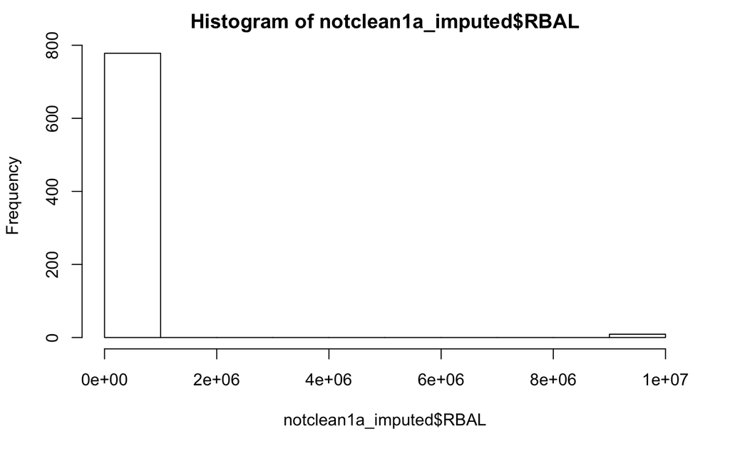

```r
# use the function hist() to plot the histogram of RBAL in the data set notclean1a
hist(notclean1a_imputed$RBAL)
```

```r
# first replace values larger than 2000000 to be NA
notclean1a_imputed$RBAL_imputed_random_outlier <- notclean1a_imputed$RBAL_imputed_random
notclean1a_imputed$RBAL_imputed_random_outlier[notclean1a_imputed$RBAL_imputed_random_outlier>=2000000] <- NA
# then impute missing values (NAs) as done above
```

```r
# now the max of RBAL becomes 91447
summary(notclean1a_imputed)
```

```
 213 values imputed to 49.14612


 213 values imputed to 17


Imputed Values:

X[[i]]
       n  missing distinct     Info     Mean      Gmd      .05      .10      .25      .50      .75
     213        0      182        1   102109   195806    196.4    579.8   1906.0   5179.0  11600.0
     .90      .95
 20795.2  27479.2

Value      0e+00 1e+05 1e+07
Frequency    208     3     2
Proportion 0.977 0.014 0.009


 213 values imputed to 20


Imputed Values:

X[[i]]
       n  missing distinct     Info     Mean      Gmd      .05      .10      .25      .50      .75
     211        2      181        1     8291     9226      196      576     1894     5088    10998
     .90      .95
   20582    25803

lowest :     0     5    25    32    47, highest: 30794 36295 54633 62383 66100

    MATCHKEY              AGE            TRADES           RBAL         AGE_imputed_mean
 Min.   :  1385102   Min.   :19.00   Min.   : 1.00   Min.   :      0   Min.   :19.00
 1st Qu.: 10172306   1st Qu.:37.50   1st Qu.:11.00   1st Qu.:   1472   1st Qu.:41.00
 Median : 13505159   Median :48.00   Median :17.00   Median :   4527   Median :49.15
 Mean   : 24495037   Mean   :49.15   Mean   :18.48   Mean   : 121507   Mean   :49.15
 3rd Qu.: 15856683   3rd Qu.:59.00   3rd Qu.:24.00   3rd Qu.:   9562   3rd Qu.:56.00
 Max.   :102467565   Max.   :99.00   Max.   :99.00   Max.   :9999999   Max.   :99.00
                     NA's   :213     NA's   :213     NA's   :213
 TRADES_imputed_median RBAL_imputed_random AGE_imputed_20  RBAL_imputed_random_outlier
 Min.   : 1.00         Min.   :      0     Min.   :19.00   Min.   :    0
 1st Qu.:12.00         1st Qu.:   1633     1st Qu.:25.00   1st Qu.: 1600
 Median :17.00         Median :   4692     Median :43.00   Median : 4634
 Mean   :18.16         Mean   : 117376     Mean   :42.94   Mean   : 7458
 3rd Qu.:22.00         3rd Qu.:   9769     3rd Qu.:56.00   3rd Qu.: 9440
 Max.   :99.00         Max.   :9999999     Max.   :99.00   Max.   :91447
                                                           NA's   :11
```

```r
# impute missing values in RBAL randomly
notclean1a_imputed$RBAL_imputed_random_outlier <- with(notclean1a_imputed, impute(RBAL_imputed_random_outlier, 'random'))
```

```r
summary(notclean1a_imputed)
```

```
 213 values imputed to 49.14612


 213 values imputed to 17


Imputed Values:

X[[i]]
       n  missing distinct     Info     Mean      Gmd      .05      .10      .25      .50      .75
     213        0      182        1   102109   195806    196.4    579.8   1906.0   5179.0  11600.0
     .90      .95
 20795.2  27479.2

Value      0e+00 1e+05 1e+07
Frequency    208     3     2
Proportion 0.977 0.014 0.009


 213 values imputed to 20


Imputed Values:

 [1]  1640  5999  6721  7352 10298  1640 10568   864     0  7218  4495


Imputed Values:

 [1]  1640  5999  6721  7352 10298  1640 10568   864     0  7218  4495

    MATCHKEY              AGE            TRADES           RBAL         AGE_imputed_mean
 Min.   :  1385102   Min.   :19.00   Min.   : 1.00   Min.   :      0   Min.   :19.00
 1st Qu.: 10172306   1st Qu.:37.50   1st Qu.:11.00   1st Qu.:   1472   1st Qu.:41.00
 Median : 13505159   Median :48.00   Median :17.00   Median :   4527   Median :49.15
 Mean   : 24495037   Mean   :49.15   Mean   :18.48   Mean   : 121507   Mean   :49.15
 3rd Qu.: 15856683   3rd Qu.:59.00   3rd Qu.:24.00   3rd Qu.:   9562   3rd Qu.:56.00
 Max.   :102467565   Max.   :99.00   Max.   :99.00   Max.   :9999999   Max.   :99.00
                     NA's   :213     NA's   :213     NA's   :213
 TRADES_imputed_median RBAL_imputed_random AGE_imputed_20  RBAL_imputed_random_outlier
 Min.   : 1.00         Min.   :      0     Min.   :19.00   Min.   :    0
 1st Qu.:12.00         1st Qu.:   1633     1st Qu.:25.00   1st Qu.: 1619
 Median :17.00         Median :   4692     Median :43.00   Median : 4635
 Mean   :18.16         Mean   : 117376     Mean   :42.94   Mean   : 7432
 3rd Qu.:22.00         3rd Qu.:   9769     3rd Qu.:56.00   3rd Qu.: 9411
 Max.   :99.00         Max.   :9999999     Max.   :99.00   Max.   :91447
```

#### 2.4 Transform and Discretize Variables

##### transform variables

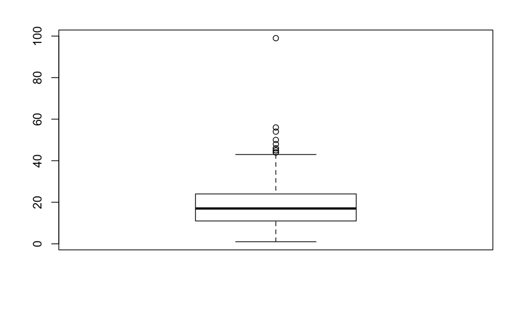

```r
boxplot(as.numeric(notclean1a_imputed$TRADES))
```

```r
# compute the log transformation
notclean1a_imputed$TRADES_imputed_median_log <- log(notclean1a_imputed$TRADES_imputed_median)
?log
```

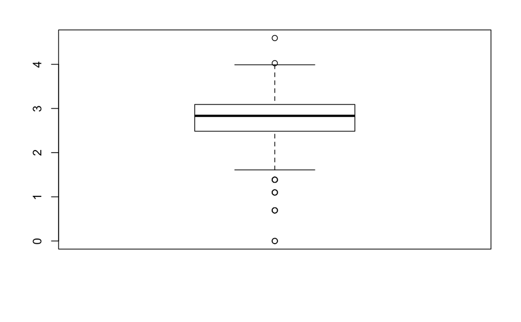

```r
boxplot(as.numeric(notclean1a_imputed$TRADES_imputed_median_log))
```

```r
head(notclean1a_imputed, 5)
```

|  | MATCHKEY | AGE | TRADES | RBAL | AGE_imputed_mean | TRADES_imputed_median | RBAL_imputed_random | AGE_imputed_20 | RBAL_imputed_random_outlier | TRADES_imputed_median_log |
| --- | --- | --- | --- | --- | --- | --- | --- | --- | --- | --- |
| 1 | 1385102 | 40 | 15 | 0 | 40 | 15 | 0 | 40 | 0 | 2.708050 |
| 2 | 1390425 | 62 | 23 | 25946 | 62 | 23 | 25946 | 62 | 25946 | 3.135494 |
| 3 | 1439834 | 43 | 32 | 8318 | 43 | 32 | 8318 | 43 | 8318 | 3.465736 |
| 4 | 1442215 | 60 | 39 | 38094 | 60 | 39 | 38094 | 60 | 38094 | 3.663562 |
| 5 | 1570044 | 43 | 23 | 33500 | 43 | 23 | 33500 | 43 | 33500 | 3.135494 |

##### discretize variables

```r
# install the package only if it is not installed
if (!require(arules)) {
  install.packages("arules")
}
```

```r
library(arules)
```

###### unsupervised discretization

```r
notclean1a_imputed$AGE_imputed_mean_cat_interval <- discretize(notclean1a_imputed$AGE_imputed_mean, method = "interval", breaks = 3)
```

```r
?discretize
```

```
Restarting R session...
```

```r
notclean1a_imputed$AGE_imputed_mean_cat_interval2 <- discretize(notclean1a_imputed$AGE_imputed_mean, method = "interval", breaks = 3, right = TRUE)
```

```r
notclean1a_imputed$AGE_imputed_mean_cat_interval2
```

```
   [1] [19,45.7]   (45.7,72.3] [19,45.7]   (45.7,72.3] [19,45.7]   [19,45.7]   (72.3,99]
   [8] (45.7,72.3] (72.3,99]   [19,45.7]   (45.7,72.3] (45.7,72.3] (72.3,99]   [19,45.7]
  [15] (45.7,72.3] [19,45.7]   [19,45.7]   [19,45.7]   (45.7,72.3] (45.7,72.3] (45.7,72.3]
  [22] (72.3,99]   (45.7,72.3] (45.7,72.3] (45.7,72.3] (45.7,72.3] (45.7,72.3] [19,45.7]
  [29] [19,45.7]   [19,45.7]   (45.7,72.3] (45.7,72.3] (45.7,72.3] [19,45.7]   (45.7,72.3]
  [36] (45.7,72.3] [19,45.7]   [19,45.7]   (45.7,72.3] [19,45.7]   (45.7,72.3] (45.7,72.3]
  [43] [19,45.7]   (45.7,72.3] [19,45.7]   (45.7,72.3] (72.3,99]   [19,45.7]   (45.7,72.3]
  [50] [19,45.7]   (45.7,72.3] (45.7,72.3] (45.7,72.3] (45.7,72.3] [19,45.7]   (45.7,72.3]
  [57] (45.7,72.3] (45.7,72.3] (45.7,72.3] [19,45.7]   (45.7,72.3] (45.7,72.3] (45.7,72.3]
  [64] (45.7,72.3] (72.3,99]   [19,45.7]   (45.7,72.3] (45.7,72.3] [19,45.7]   [19,45.7]
  [71] [19,45.7]   [19,45.7]   [19,45.7]   (72.3,99]   [19,45.7]   (45.7,72.3] (45.7,72.3]
  [78] [19,45.7]   (45.7,72.3] (45.7,72.3] [19,45.7]   [19,45.7]   [19,45.7]   [19,45.7]
  [85] (45.7,72.3] (45.7,72.3] (45.7,72.3] [19,45.7]   [19,45.7]   (45.7,72.3] [19,45.7]
  [92] [19,45.7]   [19,45.7]   [19,45.7]   (45.7,72.3] (45.7,72.3] [19,45.7]   [19,45.7]
  [99] [19,45.7]   (45.7,72.3] (45.7,72.3] [19,45.7]   [19,45.7]   [19,45.7]   (45.7,72.3]
```

[output cut: 133 more lines]

```r
notclean1a_imputed$AGE_imputed_mean_cat_interval3 <- discretize(notclean1a_imputed$AGE_imputed_mean, method = "interval", breaks = 3, right = TRUE, labels = c(1,2,3))
```

```r
notclean1a_imputed$AGE_imputed_mean_cat_interval3
```

```
   [1] 1 2 1 2 1 1 3 2 3 1 2 2 3 1 2 1 1 1 2 2 2 3 2 2 2 2 2 1 1 1 2 2 2 1 2 2 1 1 2 1 2 2 1 2 1 2
  [47] 3 1 2 1 2 2 2 2 1 2 2 2 2 1 2 2 2 2 3 1 2 2 1 1 1 1 1 3 1 2 2 1 2 2 1 1 1 1 2 2 2 1 1 2 1 1
  [93] 1 1 2 2 1 1 1 2 2 1 1 1 2 2 2 1 2 1 2 1 1 2 2 2 1 1 2 1 2 1 2 1 2 2 2 1 2 2 1 1 1 1 1 2 2 2
 [139] 1 3 1 2 2 2 1 1 2 2 3 1 1 2 2 2 1 2 2 3 1 2 1 2 2 1 2 1 1 1 2 2 2 1 2 3 1 2 3 2 2 2 2 3 2 3
 [185] 2 2 2 1 2 1 3 1 1 1 1 3 2 2 2 2 2 1 2 2 2 2 2 2 1 1 3 2 1 2 1 2 2 2 1 2 1 2 2 2 2 2 1 2 2 1
 [231] 2 2 2 2 1 2 1 1 1 2 2 2 2 2 2 2 2 1 3 2 1 2 1 2 2 2 1 2 2 2 1 1 1 3 2 2 1 1 1 3 2 2 1 3 2 2
 [277] 1 2 1 2 2 2 2 2 2 1 2 2 1 2 2 2 1 2 2 2 1 2 2 3 1 2 2 1 3 2 3 3 2 3 2 2 1 1 2 2 2 1 1 2 2 2
 [323] 2 2 1 2 1 1 2 1 2 2 2 1 2 2 1 2 1 1 2 1 2 2 2 2 3 2 2 2 2 2 1 2 1 2 3 2 2 2 1 2 2 1 1 1 3 2
 [369] 2 2 1 3 1 2 1 1 2 2 2 2 2 2 3 1 2 1 1 2 1 2 1 1 1 2 1 2 1 2 1 1 2 2 1 1 2 2 1 1 2 1 2 1 1 2
 [415] 2 2 2 2 1 1 1 2 2 2 2 1 2 2 3 2 2 1 1 1 1 1 2 2 1 2 2 2 3 2 2 2 2 1 2 1 2 2 2 2 2 2 1 2 1 1
 [461] 1 2 2 1 1 1 2 1 1 1 2 1 1 2 2 1 2 1 2 1 2 1 2 1 1 1 2 2 1 1 2 2 1 2 2 2 2 1 1 2 2 2 1 1 2 3
 [507] 2 1 1 2 1 1 2 1 2 2 2 1 1 2 1 1 2 1 2 1 1 2 1 2 1 1 2 2 2 1 2 1 1 1 1 2 2 2 3 2 1 2 2 1 1 2
 [553] 3 2 3 1 2 2 3 1 2 1 1 1 2 2 2 3 1 2 1 1 2 1 1 2 2 1 3 1 2 2 3 2 2 2 2 1 2 2 2 2 2 2 2 2 1 1
 [599] 2 2 2 1 1 1 2 1 1 2 2 1 2 2 1 2 2 1 2 2 2 2 1 2 2 1 2 2 1 1 2 3 2 2 1 2 2 2 2 3 2 2 2 2 2 2
 [645] 1 1 2 1 2 2 1 1 1 1 2 1 1 2 1 1 1 2 1 1 2 2 1 1 1 2 3 1 2 1 1 2 1 2 1 1 1 1 2 3 2 1 2 2 1 1
 [691] 3 1 2 1 2 2 3 2 2 1 1 1 2 3 2 1 1 2 3 3 1 2 1 1 1 2 2 2 2 2 2 2 1 2 2 1 1 2 2 1 1 1 1 2 2 2
 [737] 1 2 1 1 2 3 2 2 1 2 1 3 1 2 1 2 2 1 1 1 1 2 1 2 3 1 1 1 1 1 2 2 1 2 2 2 2 1 2 3 1 1 3 2 2 1
 [783] 1 2 2 1 2 2 2 2 3 2 1 1 3 2 2 2 1 1 1 2 2 1 2 1 1 1 1 2 1 2 2 3 2 1 2 2 2 2 2 1 2 1 1 2 1 2
 [829] 1 2 2 2 1 2 1 2 2 2 1 2 1 2 2 2 1 1 1 1 2 1 1 2 2 1 1 2 2 2 2 3 1 2 1 2 3 1 2 2 2 2 2 2 2 2
 [875] 2 2 2 2 2 2 2 2 2 2 2 2 2 2 2 2 2 2 2 2 2 2 2 2 2 2 2 2 2 2 2 2 2 2 2 2 2 2 2 2 2 2 2 2 2 2
 [921] 2 2 2 2 2 2 2 2 2 2 2 2 2 2 2 2 2 2 2 2 2 2 2 2 2 2 2 2 2 2 2 2 2 2 2 2 2 2 2 2 2 2 2 2 2 2
 [967] 2 2 2 2 2 2 2 2 2 2 2 2 2 2 2 2 2 2 2 2 2 2 2 2 2 2 2 2 2 2 2 2 2 2
attr(,"discretized:breaks")
[1] 19.00000 45.66667 72.33333 99.00000
attr(,"discretized:method")
[1] interval
Levels: 1 2 3
```

```
Restarting R session...
```

```r
# then compute the max
max(notclean1a_imputed$AGE_imputed_mean)
```

```
[1] 99
```

```r
notclean1a_imputed$AGE_imputed_mean_cat_fixed <- discretize(notclean1a_imputed$AGE_imputed_mean, method = "fixed", breaks=c(19, 40, 50, 100))
```

```r
notclean1a_imputed$AGE_imputed_mean_cat_fixed
```

```
   [1] [40,50)  [50,100] [40,50)  [50,100] [40,50)  [40,50)  [50,100] [50,100] [50,100] [19,40)
  [11] [50,100] [40,50)  [50,100] [40,50)  [50,100] [40,50)  [40,50)  [40,50)  [40,50)  [40,50)
  [21] [40,50)  [50,100] [40,50)  [40,50)  [50,100] [50,100] [40,50)  [19,40)  [40,50)  [40,50)
  [31] [50,100] [40,50)  [50,100] [19,40)  [50,100] [40,50)  [40,50)  [19,40)  [50,100] [19,40)
  [41] [50,100] [40,50)  [40,50)  [50,100] [40,50)  [40,50)  [50,100] [40,50)  [40,50)  [19,40)
  [51] [50,100] [50,100] [50,100] [50,100] [19,40)  [40,50)  [50,100] [40,50)  [50,100] [19,40)
  [61] [50,100] [50,100] [50,100] [50,100] [50,100] [19,40)  [40,50)  [40,50)  [19,40)  [40,50)
  [71] [40,50)  [19,40)  [19,40)  [50,100] [19,40)  [50,100] [50,100] [19,40)  [50,100] [40,50)
  [81] [40,50)  [19,40)  [19,40)  [19,40)  [40,50)  [40,50)  [40,50)  [19,40)  [19,40)  [50,100]
  [91] [40,50)  [40,50)  [19,40)  [40,50)  [50,100] [40,50)  [19,40)  [19,40)  [40,50)  [50,100]
 [101] [50,100] [19,40)  [19,40)  [40,50)  [50,100] [50,100] [50,100] [40,50)  [40,50)  [19,40)
 [111] [40,50)  [40,50)  [19,40)  [50,100] [50,100] [50,100] [19,40)  [19,40)  [40,50)  [19,40)
 [121] [50,100] [19,40)  [50,100] [19,40)  [50,100] [50,100] [40,50)  [19,40)  [50,100] [50,100]
 [131] [40,50)  [40,50)  [40,50)  [40,50)  [40,50)  [50,100] [40,50)  [40,50)  [40,50)  [50,100]
 [141] [19,40)  [40,50)  [50,100] [40,50)  [19,40)  [40,50)  [50,100] [50,100] [50,100] [40,50)
```

[output cut: 90 more lines]

###### supervised discretization

https://blog.revolutionanalytics.com/2015/03/r-package-smbinning-optimal-binning-for-scoring-modeling.html

#### 2.5 Subset the Dataset

##### subset observations

```r
# use the function subset() to only retrieve observations where AGE equals 99
subset_obs <- subset(notclean1a_imputed, AGE==99)
# display the subset
subset_obs
```

|  | MATCHKEY | AGE | TRADES | RBAL | AGE_imputed_mean | TRADES_imputed_median | RBAL_imputed_random | AGE_imputed_20 | RBAL_imputed_random_outlier | TRADES_imputed_median_log | AGE_imputed_mean_cat_interval | AGE_imputed_mean_cat_interval2 | AGE_imputed_mean_cat_interval3 | AGE_imputed_mean_cat_fixed |
| --- | --- | --- | --- | --- | --- | --- | --- | --- | --- | --- | --- | --- | --- | --- |
| 65 | 2780434 | 99 | 1 | 0 | 99 | 1 | 0 | 99 | 0 | 0.0000000 | [72.3,99] | (72.3,99] | 3 | [50,100] |
| 211 | 5323892 | 99 | 5 | 1056 | 99 | 5 | 1056 | 99 | 1056 | 1.6094379 | [72.3,99] | (72.3,99] | 3 | [50,100] |
| 429 | 12983675 | 99 | 5 | 0 | 99 | 5 | 0 | 99 | 0 | 1.6094379 | [72.3,99] | (72.3,99] | 3 | [50,100] |
| 579 | 14078655 | 99 | 1 | 9999998 | 99 | 1 | 9999998 | 99 | 11145 | 0.0000000 | [72.3,99] | (72.3,99] | 3 | [50,100] |
| 630 | 14316936 | 99 | 2 | 0 | 99 | 2 | 0 | 99 | 0 | 0.6931472 | [72.3,99] | (72.3,99] | 3 | [50,100] |
| 742 | 15577379 | 99 | 5 | 120 | 99 | 5 | 120 | 99 | 120 | 1.6094379 | [72.3,99] | (72.3,99] | 3 | [50,100] |

```r
# get the description and usage of the data set
?subset
```

##### drop or keep variables in the dataset

```r
# in the 2nd parameter, specify the columns to keep
# here AGE and RBAL
subset_vars <- subset(notclean1a_imputed, select=c(AGE, RBAL))
# display the subset
subset_vars
```

|  | AGE | RBAL |
| --- | --- | --- |
| 1 | 40 | 0 |
| 2 | 62 | 25946 |
| 3 | 43 | 8318 |
| 4 | 60 | 38094 |
| 5 | 43 | 33500 |
| 6 | 44 | 6359 |
| 7 | 75 | 1431 |
| 8 | 50 | 16152 |
| 9 | 87 | 2898 |
| 10 | 30 | 259 |

[output cut: 990 more lines]

```r
# get the description and usage of the function c()
?c
```

##### generate a random sample of the dataset

```r
# install the package only if it is not installed
if (!require(mosaic)) {
  install.packages("mosaic")
}
```

```r
library(mosaic)
```

```r
# set random seed
set.rseed(12345)
# store those 10 samples in a data frame variable named sample
sample <- resample(notclean1a_imputed, size=10, replace=FALSE, orig.id=FALSE)
# display sample
sample
```

|  | MATCHKEY | AGE | TRADES | RBAL | AGE_imputed_mean | TRADES_imputed_median | RBAL_imputed_random | AGE_imputed_20 | RBAL_imputed_random_outlier | TRADES_imputed_median_log | AGE_imputed_mean_cat_interval | AGE_imputed_mean_cat_interval2 | AGE_imputed_mean_cat_interval3 | AGE_imputed_mean_cat_fixed |
| --- | --- | --- | --- | --- | --- | --- | --- | --- | --- | --- | --- | --- | --- | --- |
| 721 | 15000508 | 51 | 28 | 3907 | 51.00000 | 28 | 3907 | 51 | 3907 | 3.332205 | [45.7,72.3) | (45.7,72.3] | 2 | [50,100] |
| 875 | 100456959 | NA | NA | NA | 49.14612 | 17 | 0 | 20 | 0 | 2.833213 | [45.7,72.3) | (45.7,72.3] | 2 | [40,50) |
| 760 | 16011362 | 60 | 10 | 3138 | 60.00000 | 10 | 3138 | 60 | 3138 | 2.302585 | [45.7,72.3) | (45.7,72.3] | 2 | [50,100] |
| 884 | 100599556 | NA | NA | NA | 49.14612 | 17 | 0 | 20 | 0 | 2.833213 | [45.7,72.3) | (45.7,72.3] | 2 | [40,50) |
| 455 | 13125173 | 56 | 11 | 5006 | 56.00000 | 11 | 5006 | 56 | 5006 | 2.397895 | [45.7,72.3) | (45.7,72.3] | 2 | [50,100] |
| 166 | 4633561 | 45 | 20 | 1068 | 45.00000 | 20 | 1068 | 45 | 1068 | 2.995732 | [19,45.7) | [19,45.7] | 1 | [40,50) |
| 324 | 11350016 | 57 | 18 | 15652 | 57.00000 | 18 | 15652 | 57 | 15652 | 2.890372 | [45.7,72.3) | (45.7,72.3] | 2 | [50,100] |
| 506 | 13574295 | 77 | 10 | 7589 | 77.00000 | 10 | 7589 | 77 | 7589 | 2.302585 | [72.3,99] | (72.3,99] | 3 | [50,100] |
| 722 | 15014542 | 65 | 34 | 2395 | 65.00000 | 34 | 2395 | 65 | 2395 | 3.526361 | [45.7,72.3) | (45.7,72.3] | 2 | [50,100] |
| 981 | 102032487 | NA | NA | NA | 49.14612 | 17 | 3918 | 20 | 3918 | 2.833213 | [45.7,72.3) | (45.7,72.3] | 2 | [40,50) |

#### 2.6 Save Data from R into csv File

##### save the data from R into csv file

```r
# save the data frame named sample to the local file sample.csv
write.csv(sample, file = "sample.csv",row.names=FALSE)
# get the description and usage of the function write.csv()
?write.csv
```

#### 2.7 Work with Other File Formats

- Text file
- Excel
- SAS data file
- SPSS data file
- HTML
- MySQL database